# R for Data Science

### Chapter Two

Second set of data

```r
diamonds
```

```
## # A tibble: 53,940 x 10
##    carat       cut color clarity depth table price     x     y     z
##    <dbl>     <ord> <ord>   <ord> <dbl> <dbl> <int> <dbl> <dbl> <dbl>
##  1  0.23     Ideal     E     SI2  61.5    55   326  3.95  3.98  2.43
##  2  0.21   Premium     E     SI1  59.8    61   326  3.89  3.84  2.31
##  3  0.23      Good     E     VS1  56.9    65   327  4.05  4.07  2.31
##  4  0.29   Premium     I     VS2  62.4    58   334  4.20  4.23  2.63
##  5  0.31      Good     J     SI2  63.3    58   335  4.34  4.35  2.75
##  6  0.24 Very Good     J    VVS2  62.8    57   336  3.94  3.96  2.48
##  7  0.24 Very Good     I    VVS1  62.3    57   336  3.95  3.98  2.47
##  8  0.26 Very Good     H     SI1  61.9    55   337  4.07  4.11  2.53
##  9  0.22      Fair     E     VS2  65.1    61   337  3.87  3.78  2.49
## 10  0.23 Very Good     H     VS1  59.4    61   338  4.00  4.05  2.39
## # ... with 53,930 more rows
```

Examples of graphs using ggplots

```r
ggplot(data = diamonds) +
  geom_bar(mapping = aes(x = cut))
```

[output not shown]

```r
#creates a basic bar graph

ggplot(data = diamonds) +
  stat_count(mapping = aes(x = cut))
```

[output not shown]

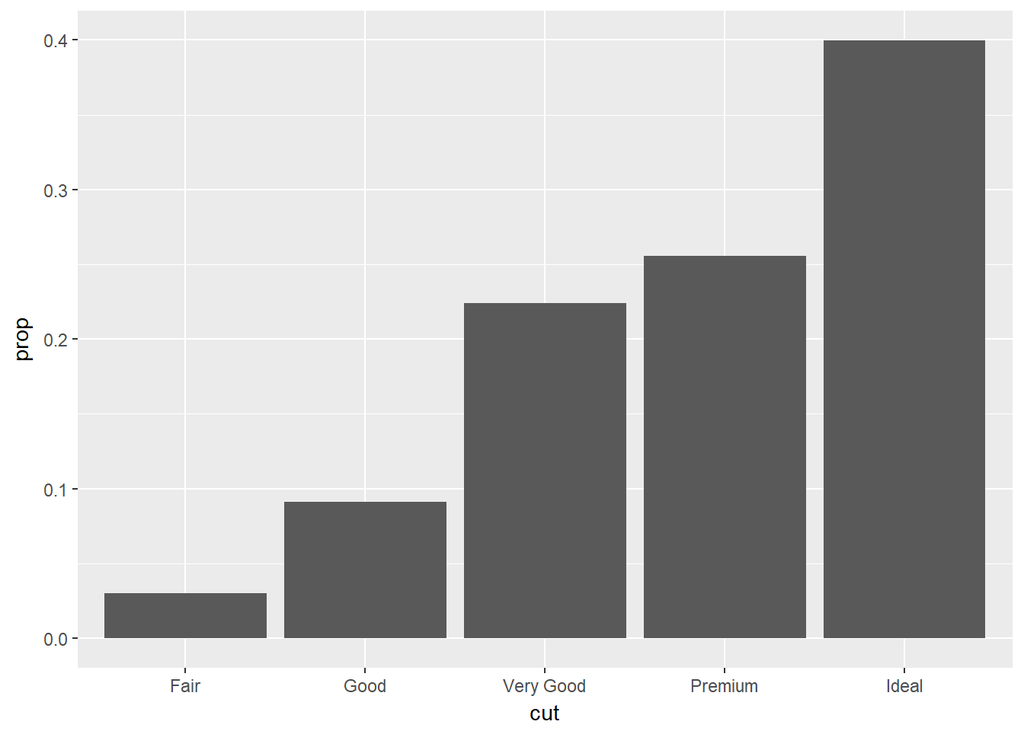

```r
#makes the same bar graph different code

ggplot(data = diamonds) +
  geom_bar(mapping = aes(x = cut, y = ..prop.., group = 1))
```

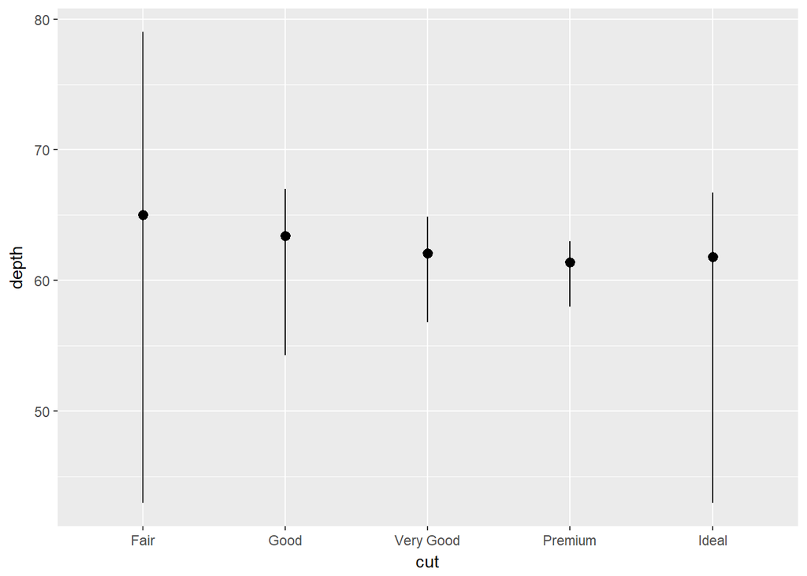

```r
#makes a bar graph of proportions rather than bulk numbers

ggplot(data = diamonds) +
  stat_summary(
    mapping = aes(x = cut, y = depth),
    fun.ymin = min,
    fun.ymax = max,
    fun.y = median
  )
```

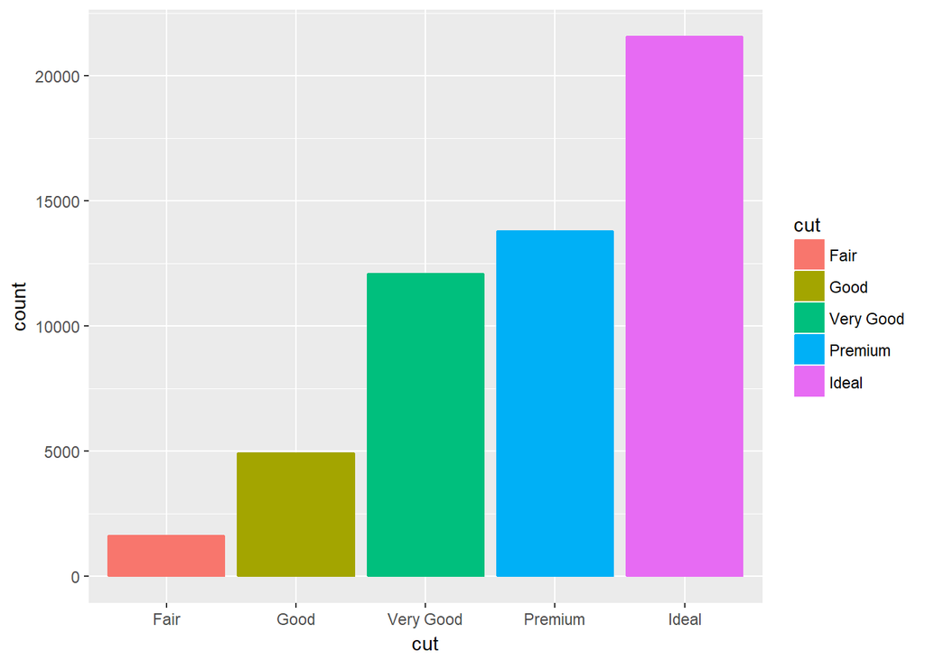

```r
#makes a box graph here comparing cut and depth they are found at

ggplot(data = diamonds) +
  geom_bar(mapping = aes(x = cut, color = cut, fill = cut))
```

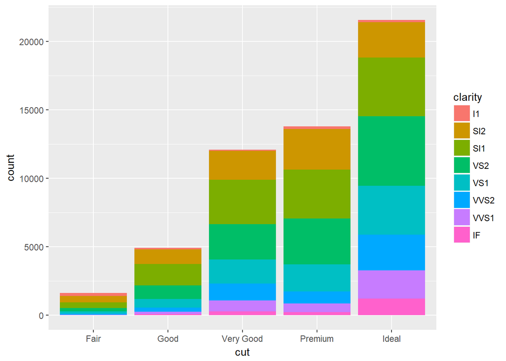

```r
#color adds an outline, fill fills thebars a color

ggplot(data = diamonds) +
  geom_bar(mapping = aes(x = cut, fill = clarity))
```

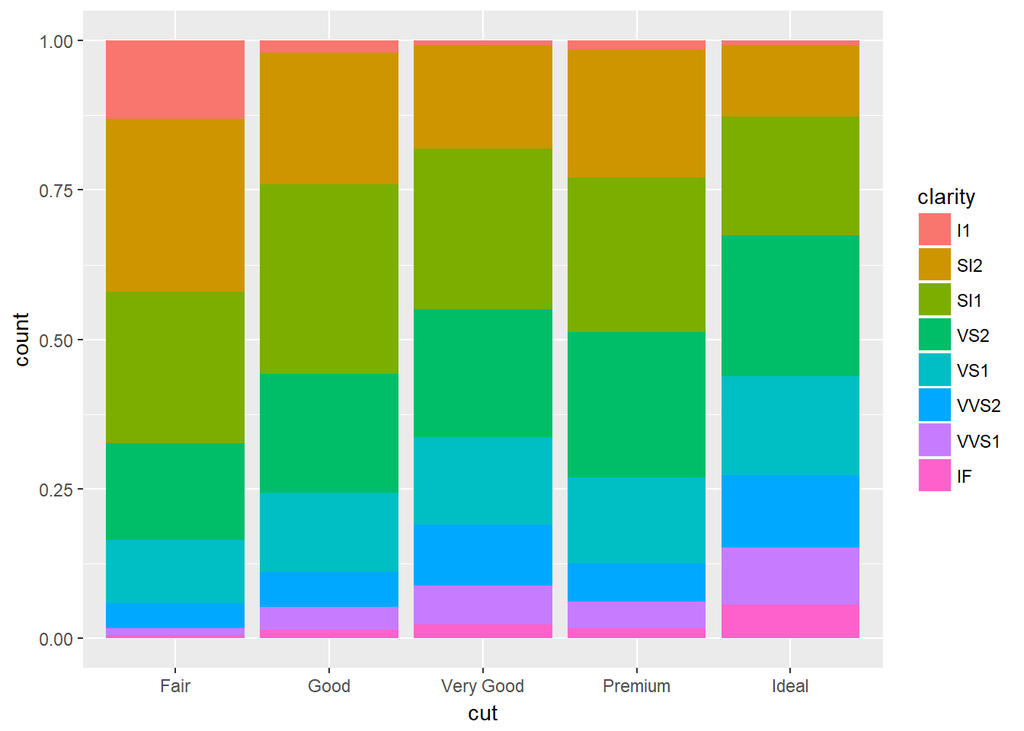

```r
#if you use a second varible will fill the bars in proportion to the bar, here cut broken down into clarity

ggplot(data = diamonds) +
  geom_bar(mapping = aes(x = cut, fill = clarity),
  position = "fill"
  )
```

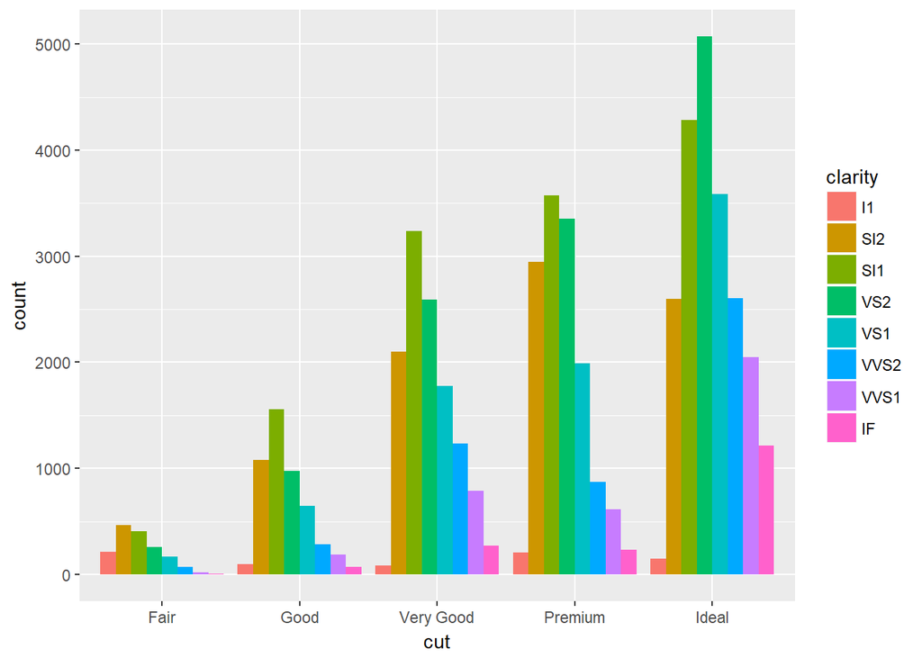

```r
#makes the bars even but shows proportion of cut compared to clarity better

ggplot(data = diamonds) +
  geom_bar(mapping = aes(x = cut, fill = clarity),
           position = "dodge"
  )
```

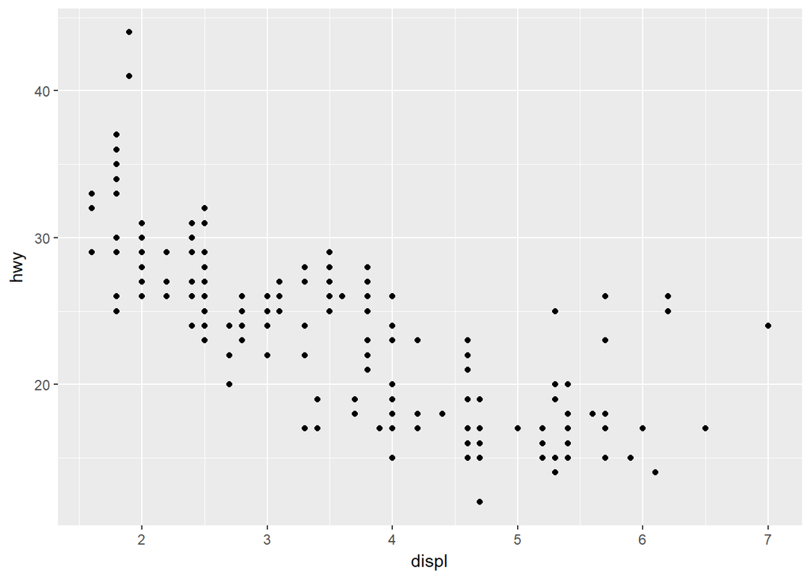

```r
#makes seprate bars to better show numbers over proportions

ggplot(data = mpg) +
  geom_point(mapping = aes(x = displ, y = hwy), postion = "jitter")
```

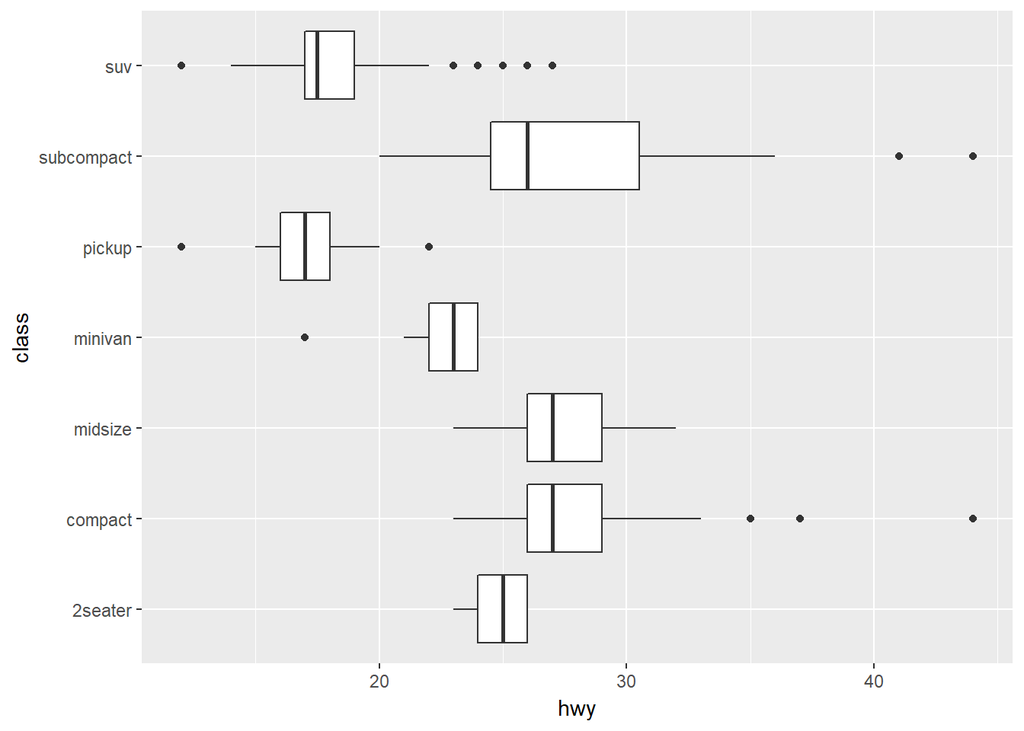

```r
#makes it so each point is represented, but with loss of accuracy


ggplot(data = mpg, mapping = aes(x = class, y = hwy)) +
  geom_boxplot() +
  coord_flip()
```

```r
#makes a box plot of class compared to highway milage, coord_flip() flips the axis
```

## Data Transformation

Note that the veiw() command will not open a window in the browser, but in Rstudio it will open a seprate window to veiw all of the data.

### Chapter Three

Use this package for the dataset that will be used

```r
library(nycflights13)
```

The data set shown in table format two different ways

```r
nycflights13::flights
```

```
## # A tibble: 336,776 x 19
##     year month   day dep_time sched_dep_time dep_delay arr_time
##    <int> <int> <int>    <int>          <int>     <dbl>    <int>
##  1  2013     1     1      517            515         2      830
##  2  2013     1     1      533            529         4      850
##  3  2013     1     1      542            540         2      923
##  4  2013     1     1      544            545        -1     1004
##  5  2013     1     1      554            600        -6      812
##  6  2013     1     1      554            558        -4      740
##  7  2013     1     1      555            600        -5      913
##  8  2013     1     1      557            600        -3      709
##  9  2013     1     1      557            600        -3      838
## 10  2013     1     1      558            600        -2      753
## # ... with 336,766 more rows, and 12 more variables: sched_arr_time <int>,
## #   arr_delay <dbl>, carrier <chr>, flight <int>, tailnum <chr>,
## #   origin <chr>, dest <chr>, air_time <dbl>, distance <dbl>, hour <dbl>,
## #   minute <dbl>, time_hour <dttm>
```

```r
#our data set

View(flights)
#opens a window so you can see all the data not just an example
```

Some examples of the filter command

```r
filter(flights, month == 1, day == 1)
```

```
## # A tibble: 842 x 19
##     year month   day dep_time sched_dep_time dep_delay arr_time
##    <int> <int> <int>    <int>          <int>     <dbl>    <int>
##  1  2013     1     1      517            515         2      830
##  2  2013     1     1      533            529         4      850
##  3  2013     1     1      542            540         2      923
##  4  2013     1     1      544            545        -1     1004
##  5  2013     1     1      554            600        -6      812
##  6  2013     1     1      554            558        -4      740
##  7  2013     1     1      555            600        -5      913
##  8  2013     1     1      557            600        -3      709
##  9  2013     1     1      557            600        -3      838
## 10  2013     1     1      558            600        -2      753
## # ... with 832 more rows, and 12 more variables: sched_arr_time <int>,
## #   arr_delay <dbl>, carrier <chr>, flight <int>, tailnum <chr>,
## #   origin <chr>, dest <chr>, air_time <dbl>, distance <dbl>, hour <dbl>,
## #   minute <dbl>, time_hour <dttm>
```

```r
#filters the data by first month first day only

(jan1 <- filter(flights, month == 1, day == 1))
```

```
## # A tibble: 842 x 19
##     year month   day dep_time sched_dep_time dep_delay arr_time
##    <int> <int> <int>    <int>          <int>     <dbl>    <int>
##  1  2013     1     1      517            515         2      830
##  2  2013     1     1      533            529         4      850
##  3  2013     1     1      542            540         2      923
##  4  2013     1     1      544            545        -1     1004
##  5  2013     1     1      554            600        -6      812
##  6  2013     1     1      554            558        -4      740
##  7  2013     1     1      555            600        -5      913
##  8  2013     1     1      557            600        -3      709
##  9  2013     1     1      557            600        -3      838
## 10  2013     1     1      558            600        -2      753
## # ... with 832 more rows, and 12 more variables: sched_arr_time <int>,
## #   arr_delay <dbl>, carrier <chr>, flight <int>, tailnum <chr>,
## #   origin <chr>, dest <chr>, air_time <dbl>, distance <dbl>, hour <dbl>,
## #   minute <dbl>, time_hour <dttm>
```

```r
#saves that filter into varible jan1

nov_dec <- filter(flights, month %in% c(11, 12))
#assigns all of the nov and dec flights into a table

View(nov_dec)
#test to see that it does
```

Some examples of arrange command

```r
View(arrange(flights, year, month, day))
#arranges from low to high by year, month, and day

arrange(flights, desc(arr_delay))
```

```
## # A tibble: 336,776 x 19
##     year month   day dep_time sched_dep_time dep_delay arr_time
##    <int> <int> <int>    <int>          <int>     <dbl>    <int>
##  1  2013     1     9      641            900      1301     1242
##  2  2013     6    15     1432           1935      1137     1607
##  3  2013     1    10     1121           1635      1126     1239
##  4  2013     9    20     1139           1845      1014     1457
##  5  2013     7    22      845           1600      1005     1044
##  6  2013     4    10     1100           1900       960     1342
##  7  2013     3    17     2321            810       911      135
##  8  2013     7    22     2257            759       898      121
##  9  2013    12     5      756           1700       896     1058
## 10  2013     5     3     1133           2055       878     1250
## # ... with 336,766 more rows, and 12 more variables: sched_arr_time <int>,
## #   arr_delay <dbl>, carrier <chr>, flight <int>, tailnum <chr>,
## #   origin <chr>, dest <chr>, air_time <dbl>, distance <dbl>, hour <dbl>,
## #   minute <dbl>, time_hour <dttm>
```

```r
#aranges from high to low the delay, note na or no vaule data points are moved to the end
```

Some examples of select command

```r
select(flights, year, month, day)
```

```
## # A tibble: 336,776 x 3
##     year month   day
##    <int> <int> <int>
##  1  2013     1     1
##  2  2013     1     1
##  3  2013     1     1
##  4  2013     1     1
##  5  2013     1     1
##  6  2013     1     1
##  7  2013     1     1
##  8  2013     1     1
##  9  2013     1     1
## 10  2013     1     1
## # ... with 336,766 more rows
```

```r
#selects only certain columns, can use for example (year:day) all columns between two columns or -(year:day) to
#selects everything but the columns you specifiy in this example day, month, and year
#select also uses common string functions like contains, starts_with, etc.

flights_sml <- select(flights, year:day, ends_with("delay"), distance, air_time)
#makes a sample set of day, month, year, all delay sets, distance, and air time
```

Some examples of mutate command

```r
mutate(flights_sml, gain = arr_delay - dep_delay, speed = distance / air_time * 60)
```

```
## # A tibble: 336,776 x 9
##     year month   day dep_delay arr_delay distance air_time  gain    speed
##    <int> <int> <int>     <dbl>     <dbl>    <dbl>    <dbl> <dbl>    <dbl>
##  1  2013     1     1         2        11     1400      227     9 370.0441
##  2  2013     1     1         4        20     1416      227    16 374.2731
##  3  2013     1     1         2        33     1089      160    31 408.3750
##  4  2013     1     1        -1       -18     1576      183   -17 516.7213
##  5  2013     1     1        -6       -25      762      116   -19 394.1379
##  6  2013     1     1        -4        12      719      150    16 287.6000
##  7  2013     1     1        -5        19     1065      158    24 404.4304
##  8  2013     1     1        -3       -14      229       53   -11 259.2453
##  9  2013     1     1        -3        -8      944      140    -5 404.5714
## 10  2013     1     1        -2         8      733      138    10 318.6957
## # ... with 336,766 more rows
```

```r
#creates columns for gain and speed based off of our parameters

transmute(flights, gain = arr_delay - dep_delay, hours = air_time / 60, gain_per_hour = gain/hours )
```

```
## # A tibble: 336,776 x 3
##     gain     hours gain_per_hour
##    <dbl>     <dbl>         <dbl>
##  1     9 3.7833333      2.378855
##  2    16 3.7833333      4.229075
##  3    31 2.6666667     11.625000
##  4   -17 3.0500000     -5.573770
##  5   -19 1.9333333     -9.827586
##  6    16 2.5000000      6.400000
##  7    24 2.6333333      9.113924
##  8   -11 0.8833333    -12.452830
##  9    -5 2.3333333     -2.142857
## 10    10 2.3000000      4.347826
## # ... with 336,766 more rows
```

```r
#only keeps new varibles that you create using your parameters
```

Some basic commands

```r
x <- 1:10
#make x 1-10
lag(x)
```

```
##  [1] NA  1  2  3  4  5  6  7  8  9
```

```r
#looks at x from one spot the the left so NA to 9 instead
lead(x)
```

```
##  [1]  2  3  4  5  6  7  8  9 10 NA
```

```r
#looks at x from one spot the the right so 2 to NA instead
cumsum(x)
```

```
##  [1]  1  3  6 10 15 21 28 36 45 55
```

```r
#adds all values
cummean(x)
```

```
##  [1] 1.0 1.5 2.0 2.5 3.0 3.5 4.0 4.5 5.0 5.5
```

```r
#finds rolling mean
min_rank(x)
```

```
##  [1]  1  2  3  4  5  6  7  8  9 10
```

```r
#ranks from smallest to largest
```

Some examples of using these commands in tandum

```r
by_day <- group_by(flights, year, month, day)
#group by_day in flights by year, month, day
summarise(by_day, delay = mean(dep_delay, na.rm = TRUE))
```

```
## # A tibble: 365 x 4
## # Groups:   year, month [?]
##     year month   day     delay
##    <int> <int> <int>     <dbl>
##  1  2013     1     1 11.548926
##  2  2013     1     2 13.858824
##  3  2013     1     3 10.987832
##  4  2013     1     4  8.951595
##  5  2013     1     5  5.732218
##  6  2013     1     6  7.148014
##  7  2013     1     7  5.417204
##  8  2013     1     8  2.553073
##  9  2013     1     9  2.276477
## 10  2013     1    10  2.844995
## # ... with 355 more rows
```

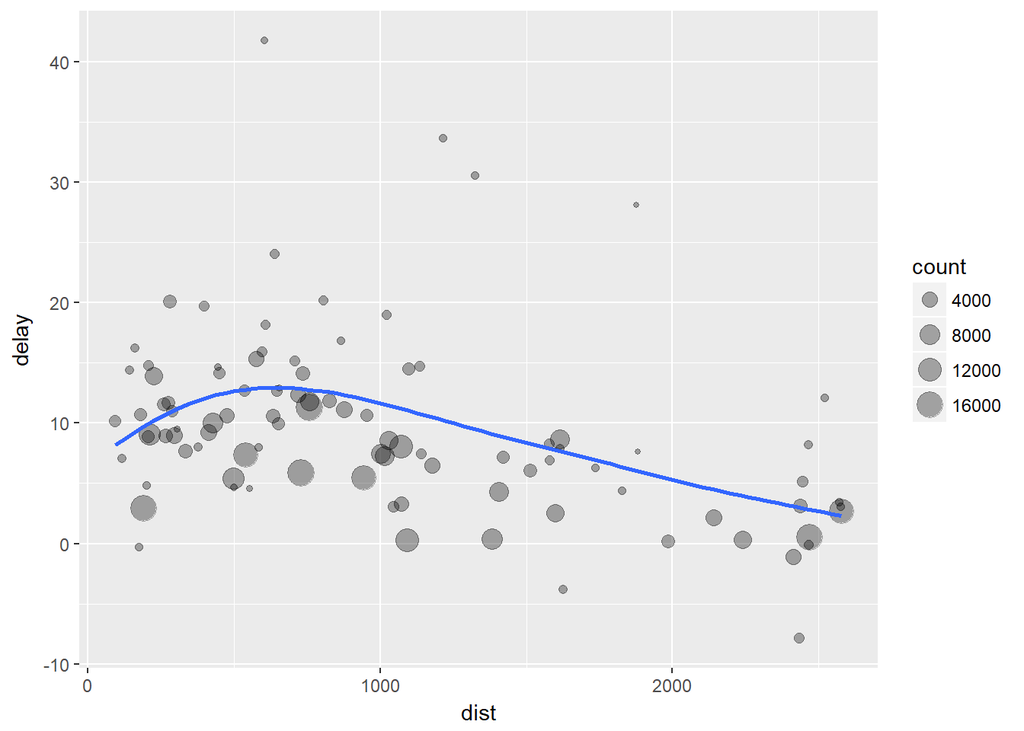

```r
#finds the mean delay for a day exculding NA's

by_dest <- group_by(flights, dest)
delay <- summarize(by_dest, count = n(), dist = mean(distance, na.rm = TRUE), delay = mean(arr_delay, na.rm = TRUE))
delay <- filter(delay, count > 20, dest != "HNL")
ggplot(data = delay, mapping = aes(x = dist, y = delay)) +
  geom_point(aes(size = count), alpha = 1/3) +
  geom_smooth(se = FALSE)
```

```r
#groups flights by destionation, summarizes to coute distance, average delay, and # of flights
#filter to remove short flights and honolulu since it is an outliear

delays <- flights %>%
  group_by(dest) %>%
  summarize(count = n(), dist = mean(distance, na.ra = TRUE), delay = mean(arr_delay, na.ra = TRUE)) %>%
  filter(count > 20, dest != "HNL")
#%>% means or can be thought of as then so create a varible based on our data THEN group the data by destionation
#THEN create a summary with a count and dist as a mean of the distances and delay as the mean of delays from short to highest
#THEN filter out our short flights and Honolulu since it is an outliear
```

## EDA

### Preface

Now we are using some of our skills to do some baseline anyalitics on the data. This will be done often by using histograms and finding “odd” data and/or looking for trends to hone in on. Then using filters and sorters to look at the data and find insight.

### Chapter 4

Starting with some examples from the book.

```r
library(tidyverse)

ggplot(data = diamonds) +
  geom_bar(mapping = aes(x = cut))
```

[output not shown]

```r
#an example of a categorical data point

diamonds %>%
  count(cut)
```

```
## # A tibble: 5 x 2
##         cut     n
##       <ord> <int>
## 1      Fair  1610
## 2      Good  4906
## 3 Very Good 12082
## 4   Premium 13791
## 5     Ideal 21551
```

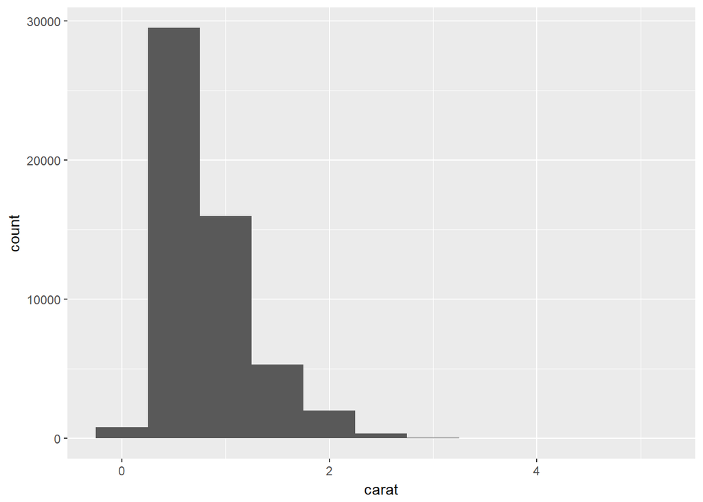

```r
#gives the raw numbers for each bar

ggplot(data = diamonds) +
  geom_histogram(mapping = aes(x = carat), binwidth = 0.5)
```

```r
#an example of a continusous data point graphed

diamonds %>%
  count(cut_width(carat, 0.5))
```

```
## # A tibble: 11 x 2
##    `cut_width(carat, 0.5)`     n
##                     <fctr> <int>
##  1            [-0.25,0.25]   785
##  2             (0.25,0.75] 29498
##  3             (0.75,1.25] 15977
##  4             (1.25,1.75]  5313
##  5             (1.75,2.25]  2002
##  6             (2.25,2.75]   322
##  7             (2.75,3.25]    32
##  8             (3.25,3.75]     5
##  9             (3.75,4.25]     4
## 10             (4.25,4.75]     1
## 11             (4.75,5.25]     1
```

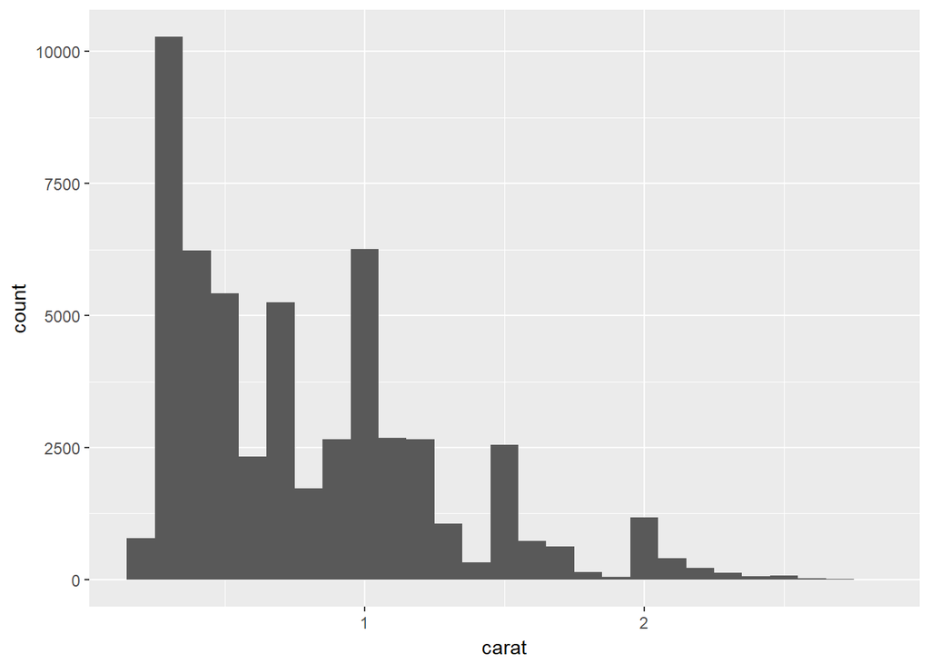

```r
#gives raw numbers in a 0.5 carat width

smaller <- diamonds %>%
  filter(carat < 3)
#create a varible of diamonds with a carat less than 3

ggplot(data = smaller, mapping = aes(x = carat)) +
  geom_histogram(binwidth = 0.1)
```

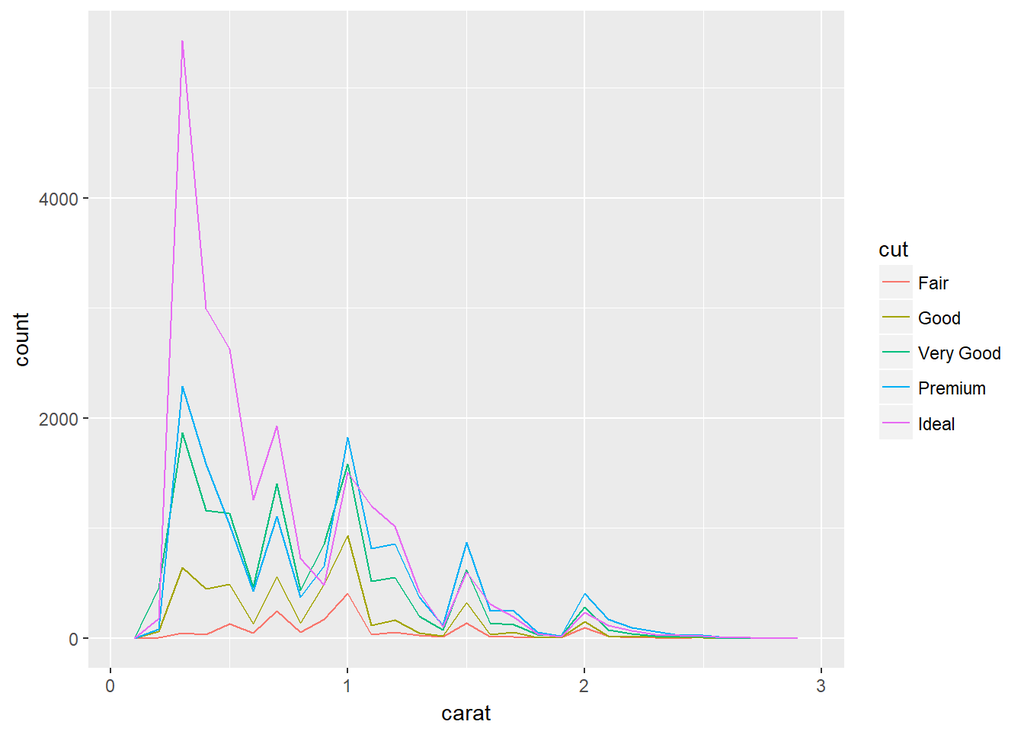

```r
#since our largest set of data is betwen 0.25 and 0.75 looking at data around that with a larger breakdown
#of 0.1 instead of 0.5

ggplot(data = smaller, mapping = aes(x = carat, color = cut)) +
  geom_freqpoly(binwidth = 0.1)
```

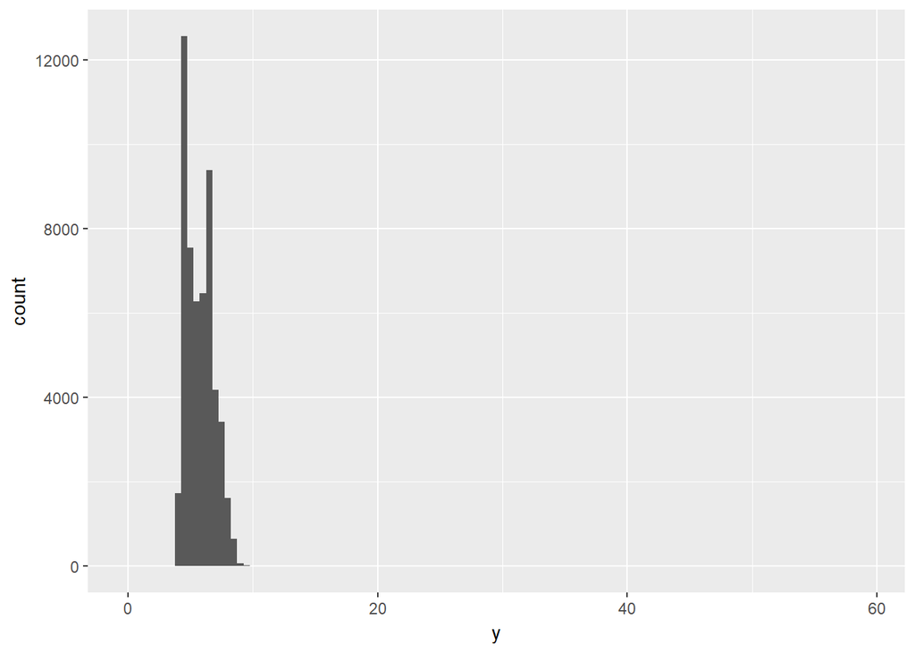

```r
#shows the same as above but with cut also shown in color so that you can see a breakdown of cut and carat

ggplot(diamonds) +
  geom_histogram(mapping = aes(x = y), binwidth = 0.5)
```

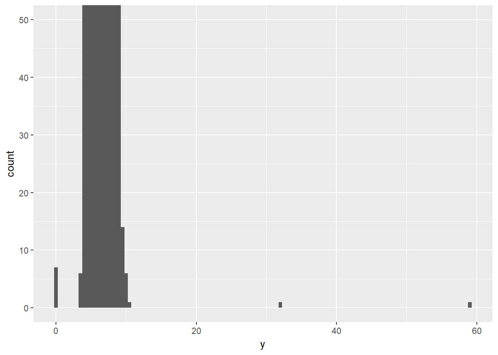

```r
#create a graph of common observations, the problem is that we cannot see the outliears in this graph

ggplot(diamonds) +
  geom_histogram(mapping = aes(x = y), binwidth = 0.5) +
  coord_cartesian(ylim = c(0, 50))
```

```r
#zooms into the yaxis to see the rare "bins" of data using coord_cartesian

unusual <- diamonds %>%
  filter(y < 3 | y > 20) %>%
  arrange(y)
#create a dara set of unusual data aka the data less then 3 and greater than 20 on the y axis

unusual
```

```
## # A tibble: 9 x 10
##   carat       cut color clarity depth table price     x     y     z
##   <dbl>     <ord> <ord>   <ord> <dbl> <dbl> <int> <dbl> <dbl> <dbl>
## 1  1.00 Very Good     H     VS2  63.3    53  5139  0.00   0.0  0.00
## 2  1.14      Fair     G     VS1  57.5    67  6381  0.00   0.0  0.00
## 3  1.56     Ideal     G     VS2  62.2    54 12800  0.00   0.0  0.00
## 4  1.20   Premium     D    VVS1  62.1    59 15686  0.00   0.0  0.00
## 5  2.25   Premium     H     SI2  62.8    59 18034  0.00   0.0  0.00
## 6  0.71      Good     F     SI2  64.1    60  2130  0.00   0.0  0.00
## 7  0.71      Good     F     SI2  64.1    60  2130  0.00   0.0  0.00
## 8  0.51     Ideal     E     VS1  61.8    55  2075  5.15  31.8  5.12
## 9  2.00   Premium     H     SI2  58.9    57 12210  8.09  58.9  8.06
```

```r
#as you can see there are some diamonds with 0's in x and y which y is a width and diamonds cannot
#have a width of 0 also they cannot have a width of 31.8 or 58.9 mm which is almost over an inch long
```

### Exploration

Now the start of using some of the ideas from the book. By asking and answering questions and looking at the data.

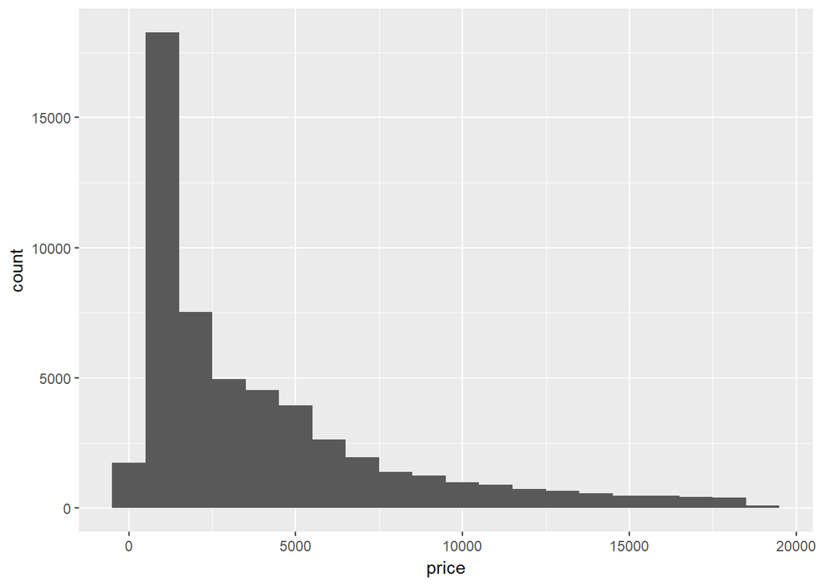

```r
ggplot(diamonds) +
  geom_histogram(mapping = aes(x = price), binwidth = 1000)
```

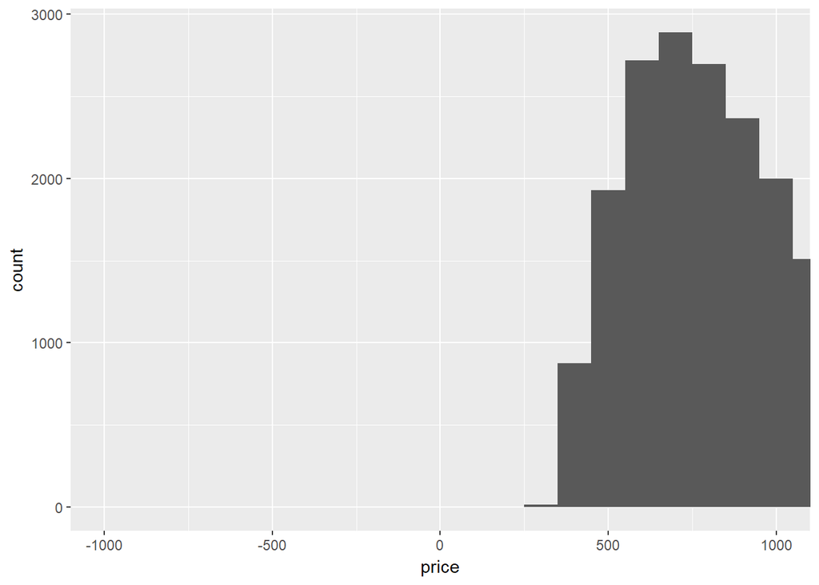

```r
#here is a histogram based on price and as you can see there are some odd data points like the price being
#below 0

ggplot(diamonds) +
  geom_histogram(mapping = aes(x = price), binwidth = 100) +
  coord_cartesian(xlim = c(-1000, 1000))
```

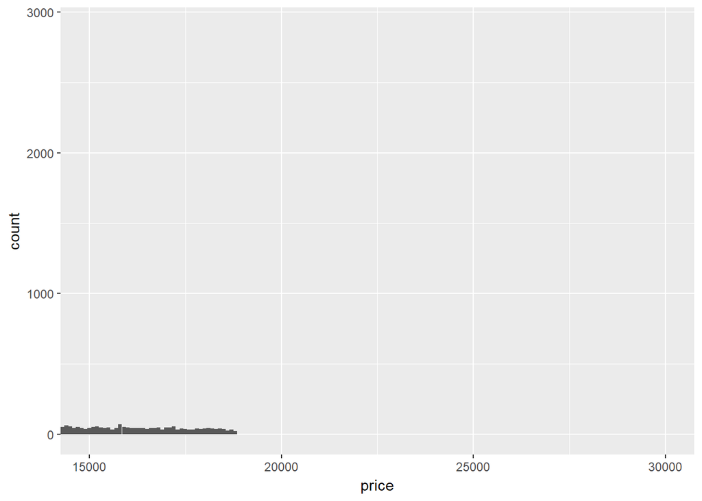

```r
#using a coord_cartesian we can see that while on the histogram it looks like there are points below 0
#in fact there are not now to look at the upper end

ggplot(diamonds) +
  geom_histogram(mapping = aes(x = price), binwidth = 100) +
  coord_cartesian(xlim = c(15000, 30000))
```

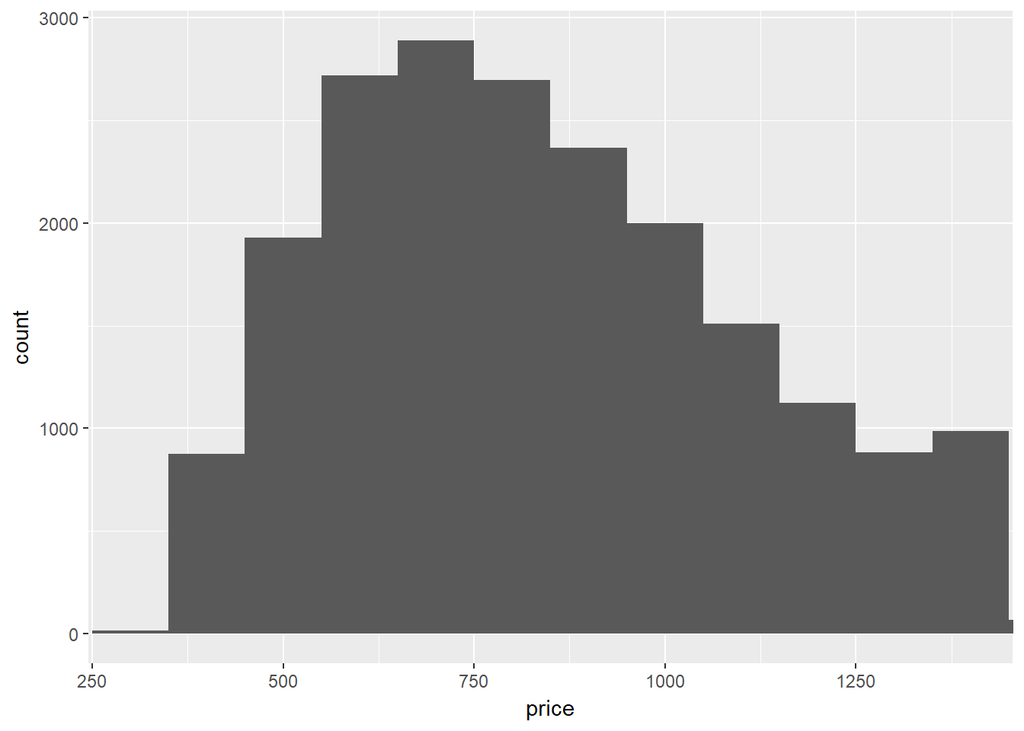

```r
#here we can see that diamonds drop off before 20000 in price


ggplot(diamonds) +
  geom_histogram(mapping = aes(x = price), binwidth = 100) +
  coord_cartesian(xlim = c(300, 1400))
```

```r
#here is the spike in out data

spike <- diamonds %>%
  filter(between(price, 300, 1400)) %>%
  arrange(price)
#narrow our window

spike
```

```
## # A tibble: 19,441 x 10
##    carat       cut color clarity depth table price     x     y     z
##    <dbl>     <ord> <ord>   <ord> <dbl> <dbl> <int> <dbl> <dbl> <dbl>
##  1  0.23     Ideal     E     SI2  61.5    55   326  3.95  3.98  2.43
##  2  0.21   Premium     E     SI1  59.8    61   326  3.89  3.84  2.31
##  3  0.23      Good     E     VS1  56.9    65   327  4.05  4.07  2.31
##  4  0.29   Premium     I     VS2  62.4    58   334  4.20  4.23  2.63
##  5  0.31      Good     J     SI2  63.3    58   335  4.34  4.35  2.75
##  6  0.24 Very Good     J    VVS2  62.8    57   336  3.94  3.96  2.48
##  7  0.24 Very Good     I    VVS1  62.3    57   336  3.95  3.98  2.47
##  8  0.26 Very Good     H     SI1  61.9    55   337  4.07  4.11  2.53
##  9  0.22      Fair     E     VS2  65.1    61   337  3.87  3.78  2.49
## 10  0.23 Very Good     H     VS1  59.4    61   338  4.00  4.05  2.39
## # ... with 19,431 more rows
```

```r
spike %>%
  count(cut_width(price, 100))
```

```
## # A tibble: 12 x 2
##    `cut_width(price, 100)`     n
##                     <fctr> <int>
##  1               [250,350]    17
##  2               (350,450]   876
##  3               (450,550]  1930
##  4               (550,650]  2717
##  5               (650,750]  2888
##  6               (750,850]  2696
##  7               (850,950]  2366
##  8          (950,1.05e+03]  2000
##  9     (1.05e+03,1.15e+03]  1510
## 10     (1.15e+03,1.25e+03]  1124
## 11     (1.25e+03,1.35e+03]   882
## 12     (1.35e+03,1.45e+03]   435
```

```r
#look at where the bulk of the data lies

spike2 <- spike %>%
  filter(between(price, 600, 800))
#narrow even more

spike2
```

```
## # A tibble: 5,695 x 10
##    carat       cut color clarity depth table price     x     y     z
##    <dbl>     <ord> <ord>   <ord> <dbl> <dbl> <int> <dbl> <dbl> <dbl>
##  1  0.29 Very Good     D    VVS2  59.1    61   600  4.33  4.37  2.57
##  2  0.30 Very Good     E     VS2  61.6    54   600  4.29  4.32  2.65
##  3  0.29     Ideal     G    VVS2  61.3    56   600  4.23  4.25  2.60
##  4  0.31     Ideal     G     VS1  62.3    54   600  4.35  4.38  2.72
##  5  0.31      Good     E     VS1  59.0    63   600  4.44  4.47  2.63
##  6  0.26 Very Good     H    VVS2  63.3    58   600  4.08  4.04  2.57
##  7  0.26   Premium     H    VVS1  62.5    58   600  4.11  4.08  2.56
##  8  0.26     Ideal     H    VVS1  61.2    56   600  4.16  4.11  2.53
##  9  0.26   Premium     H    VVS2  62.4    58   600  4.07  4.04  2.53
## 10  0.26     Ideal     H      IF  61.1    57   600  4.16  4.12  2.53
## # ... with 5,685 more rows
```

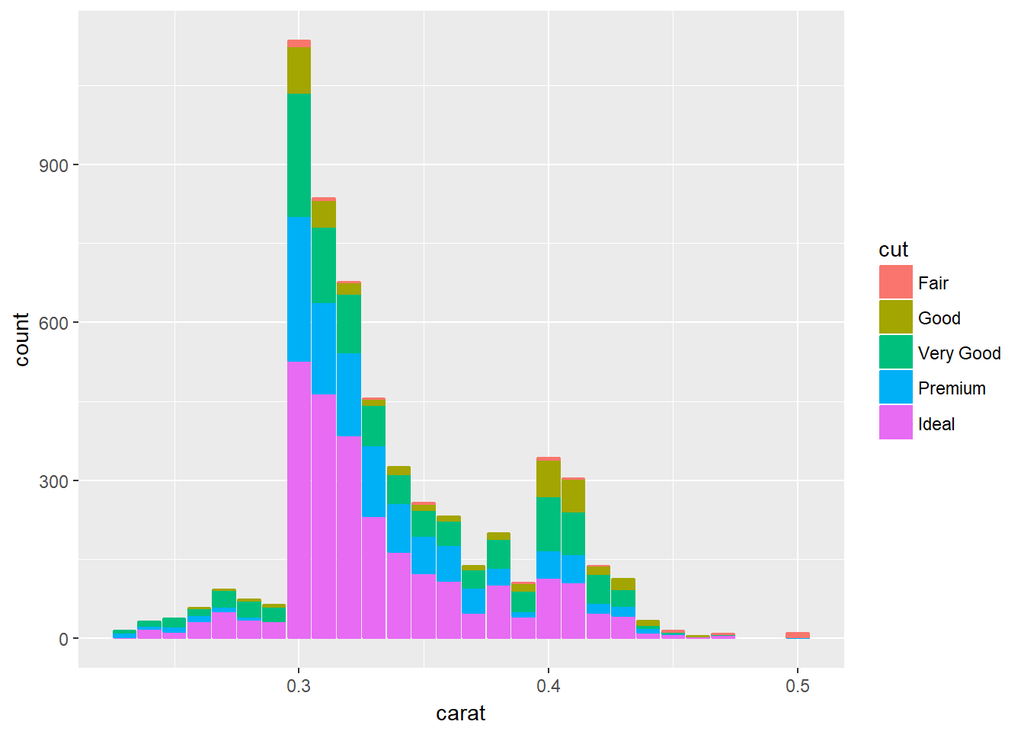

```r
ggplot(spike2) +
  geom_bar(mapping = aes(x = carat, color = cut, fill = cut))
```

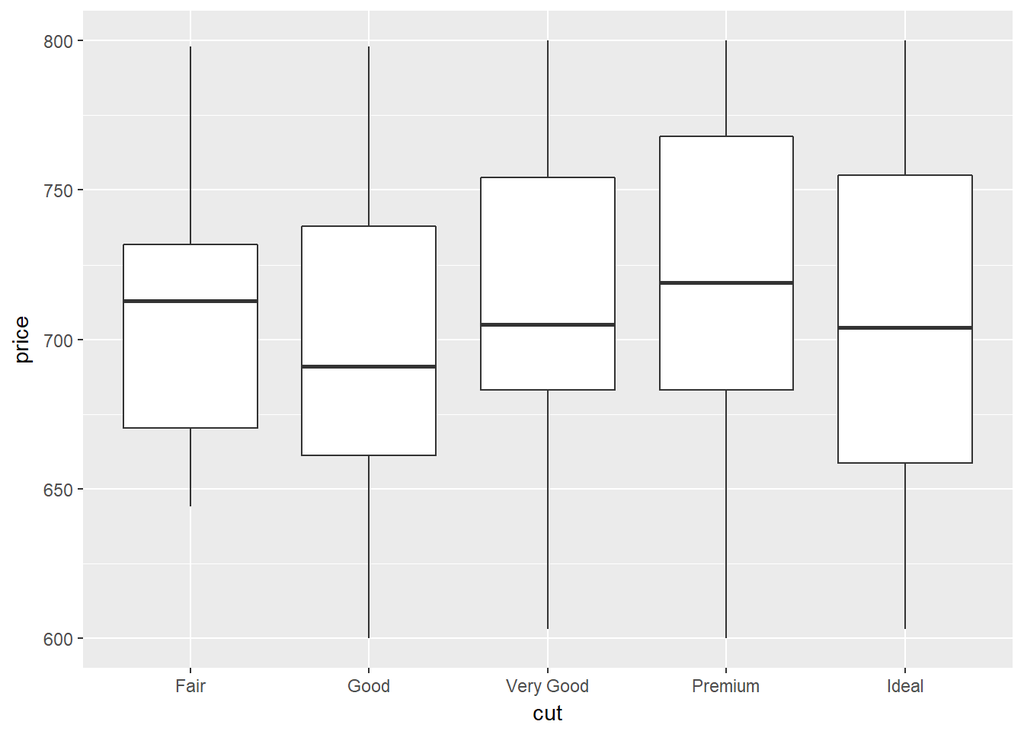

```r
#see what carat and cut diamonds are selling for in this 200 dollar range
#can see that the bulk of diamonds are sold around 600-800 dollars and are ideal cut 0.3-0.35 carat diamonds

highcarat <- spike2 %>%
  filter(between(carat, 0.4, 0.41)) %>%
  arrange(price)
#want to look at the bumb around 0.4 carats

ggplot(highcarat) +
  geom_boxplot(mapping = aes(y = price, x = cut))
```

```r
#this seems to show in the 0.4 - 0.41 carat range premium seems to sell for the most and ideal
#has some of the lowest selling diamonds which is odd

highcarat %>%
  count(cut)
```

```
## # A tibble: 5 x 2
##         cut     n
##       <ord> <int>
## 1      Fair     6
## 2      Good   132
## 3 Very Good   184
## 4   Premium   106
## 5     Ideal   219
```

```r
highcarat %>%
  count(cut_width(price, 50))
```

```
## # A tibble: 5 x 2
##   `cut_width(price, 50)`     n
##                   <fctr> <int>
## 1              [575,625]    51
## 2              (625,675]   130
## 3              (675,725]   208
## 4              (725,775]   184
## 5              (775,825]    74
```

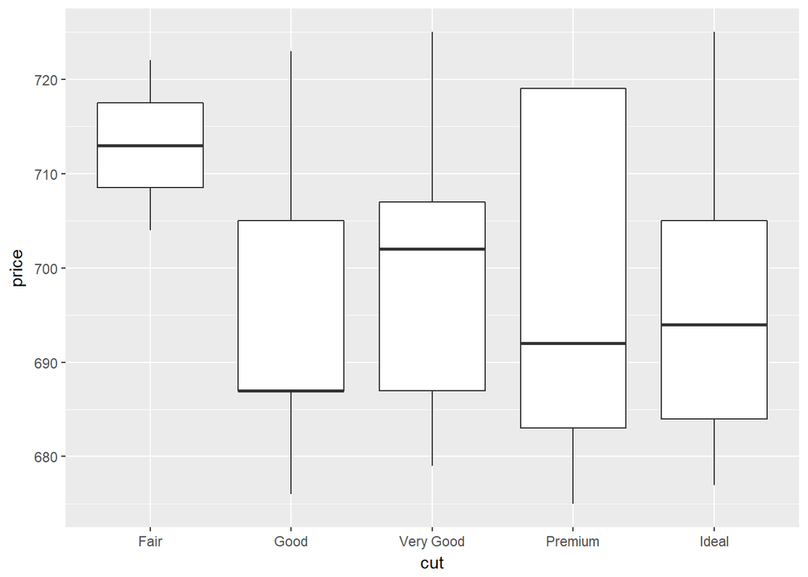

```r
#looking at what the data has in terms of numbers for cut and price
#since we are looking at price looks like price is a good data set to hone into

highcarat2 <- highcarat %>%
  filter(between(price, 675, 725))
#looking at our largest amount of data in this price point

ggplot(highcarat2) +
  geom_boxplot(mapping = aes(y = price, x = cut))
```

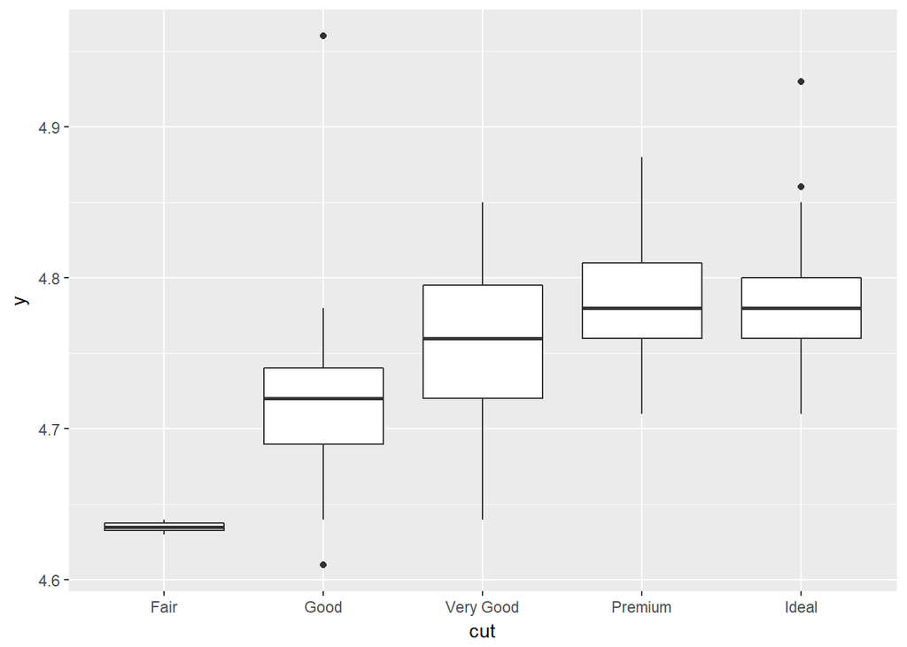

```r
#oddly the worst cut diamonds seem to be sold for more than the other cuts, while premium has a large range

ggplot(highcarat2) +
  geom_boxplot(mapping = aes(y = y, x = cut))
```

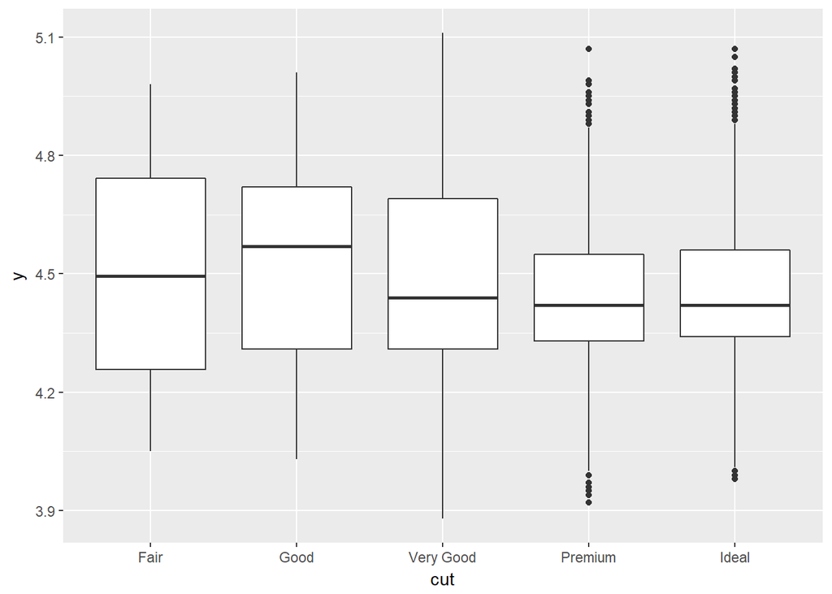

```r
#most of the y socres are around the same minus the fair diamons

ggplot(spike2) +
  geom_boxplot(mapping = aes(y = y, x = cut))
```

```r
#this is more even for the price between 600- 800 and makes more sense with fair needing higher y
#scores then premium or ideal
#this might just be an outliear unless found else where it shows little possibly because I want to narrow in my net
```

### Back to chapter 4